# Implementation of Decision Analysis to evaluate agroforestry interventions in Northern Vietnam

Hoa Do, Cory Whitney, Eike Luedeling

2019-10-31

This document illustrates the development of the mathematical model used to calculate Net Present Values (NPV) of agroforestry interventions promoted in Northwest Vietnam. To illustrate the modeling procedures we highlight NPV calculations for the decision to choose coffee-based agroforesty systems (combination of coffee, teak, plum, coffee, annual crops and grass) over conventional monocultures of maize. The same procudures and functions can be used for the other interventions. The corresponding input data tables for each system are provided in the rest of the supplementary materials.

We employed the `decisionSupport` R package and its functions to develop the model and to perform probabilistic simulations.

The `chance_event()` function was used to calculate the time series occurrence of risk events. This function required two main arguments:

1. the probability that a particular risk event will happen in a given year and
2. the time line for the simulation.

The `gompertz_yield()` function was used to calculate the yields of tree crops using identified parameters given an assumed pattern.

The value varier function `vv()` was used to produce a time series containing variation from a specified mean and a desired coefficient of variation, both of which are parameters in the input tables.

The `discount()` function was used to calculate NPV in the last step of the decision modeling procedure. The function implements discounting of future costs or benefits by a decision maker-specific discount rate, also specified in the input tables.

`decisionSupport()` function was used to conduct the full decision analyses by performing the probabilistic simulation. The function in requires two inputs: 1. a data table (.csv format) specifying the names and distributions for all uncertain variables and, 2. an R function that predicts decision outcomes based on the variables named in the data table.

`multi_EVPI()` function was used to calculate the expected value of perfect information (EVPI) for multiple variables in the model using the simulation outcome table from the `decisionSupport()`function.

First, we loaded the `decisionSupport` package in R. We defined sample values for all variables by generating a `make_variables` function to select randomly from each variable in our input table.

```r
library(decisionSupport)
make_variables <- function(est,n=1)
{x <- random(rho=est,n=n)
for(i in colnames(x))assign(i, as.numeric(x[1,i]),envir=.GlobalEnv)}
```

We applied the `make_variables` function to `estimate_read_csv` the input data table to generate one random number for each variable.

```r
make_variables(estimate_read_csv(paste("Input tables/CAFS_teak.csv",sep="")))
```

The mathematical model could then be coded. We gave the name `AF_benefit` to the function that calculates NPV.

```r
AF_benefit <- function(x,varnames)
{
#Define each variable as vectors of 25 values corresponding to 25 years of simulation

  mono_costs <- rep(0,n_years) #the annual cost of maize monoculture
  establisment_cost <- rep(0,n_years) #costs for setting up agroforestry systems (AF)
  maintenance_cost <- rep(0,n_years) #the annual cost spent on AF
  timber_yield <- rep(0,n_years) #the yield of teak
  tree_yield <- rep(0,n_years) #the yield of plum
  coffee_yield <- rep(0,n_years) #the yield of coffee
  AF_maize <- rep(0,n_years) #the yield of maize in AF
  mono_maize <- rep(0,n_years) #the yield of maize in monocultures
  grass_benefit <- rep(0,n_years) #the benefit from grass
  annual_benefit <- rep(0,n_years) #the benefit of annual crops
  reduced_soil_loss <- rep(0,n_years) #amount of soil loss reduced in AF compared to monoculture systems

  #Simulate the chance for different events to occur during the simulation period
  frost <- chance_event(coffee_risk,value_if = 1,n=n_years)
  tree.risk <- chance_event(tree_risk,value_if = 1,n=n_years)
  maize.risk <- chance_event(maize_risk,value_if = 1,n=n_years)

  #Number of timber harvests throughout 25 years of simulation
  timb_harvest <- as.numeric(1:n_years%%round(freq_tim_harvest)==0)

  #Calculate system costs and convert currency from VND to USD using currency exchange rate (cur_change) applied for any variable with monetary value (i.e. costs and benefits)
  maintenance_cost[1] <- 0
  maintenance_cost[2:4] <- vv(main_cost_stage1,CV_cost,3)/cur_change
  maintenance_cost[5:10] <- vv(main_cost_stage2,CV_cost,6)/cur_change
  maintenance_cost[11:25] <- vv(main_cost_stage3,CV_cost,15)/cur_change

  establisment_cost[1] <- establis_cost/cur_change
  establisment_cost[2:25] <- 0


  #Calculate system benefits

  #benefit of timber
  timber_benefit <- (timb_benefit*timb_harvest)/cur_change


  #benefit of trees
  tree_yield <- gompertz_yield(max_harvest = max_tree_harvest,
                             time_to_first_yield_estimate = time_first_tree_est,
                             time_to_second_yield_estimate = time_sec_tree_est,
                             first_yield_estimate_percent = first_tree_est_per,
                             second_yield_estimate_percent = sec_tree_est_per,
                             n_years=n_years,
                             var_CV=CV_tree_yield,
                             no_yield_before_first_estimate = FALSE)
  tree_yield <- tree_yield*(1-tree.risk*yield_tree_risk)
  tot_tree_yield <- tree_yield*num_of_tree
  tree_benefit <- (tot_tree_yield*tree_price)/cur_change



  #benefit of coffee
  coffee_yield[1:15] <- gompertz_yield(max_harvest = max_coff_harvest,
                                     time_to_first_yield_estimate = time_first_coff_est,
                                     time_to_second_yield_estimate = time_sec_coff_est,
                                     first_yield_estimate_percent = first_coff_est_per,
                                     second_yield_estimate_percent = sec_coff_est_per,
                                     n_years=15,
                                     var_CV = CV_coff_yield,
                                     no_yield_before_first_estimate = FALSE)

  coffee_yield[16:25] <- coffee_yield[6:15]

  #account risk of frost in the calculation of coffee yield
  coffee_yield <- coffee_yield*(1-frost*coff_frost_yield)

  tot_coffee_yield <- coffee_yield*num_coff_tree
  coffee_benefit <- (tot_coffee_yield*vv(coff_price,CV_coff_price,n_years))/cur_change

  #benefit of maize in AF systems
  time <- 1:n_years
  decay_speed_AF <- -log(1-decay_rate_AF)
  AF_maize <- min_AFmaize+(max_AFmaize-min_AFmaize)*exp(-decay_speed_AF*(time-1))
  tot_AF_maize <- vv(AF_maize*(1-maize.risk*yield_maize_risk),CV_maize_yield,n_years)
  AF_maize_benefit <- (tot_AF_maize*vv(maize_price,CV_maize_price,n_years))/cur_change


  #benefit of maize in monoculture
  decay_speed_mono <- -log(1-decay_rate_mono)
  mono_maize <- max_monomaize*exp(-decay_speed_mono*(time-1))
  tot_mono_maize <- vv(mono_maize*(1-maize.risk*yield_maize_risk),CV_maize_yield,n_years)
  mono_revenue <- (tot_mono_maize*vv(maize_price,CV_maize_price,n_years))/cur_change
  mono_costs <- vv(mono_cost,CV_cost,n_years)/cur_change
  mono_benefit <- mono_revenue-mono_costs


  #benefit of grass
  grass_benefit <- vv(grass_profit,CV_grass_profit,25)/cur_change

  #benefit of soybean
  annual_benefit[1:3] <- annual_benefit/cur_change
  annual_benefit[4:25] <- 0

  #benefit of soil erosion control
  reduced_soil_loss[1] <- 0
  reduced_soil_loss[2:10] <- reduced_percents1*mono_soil_loss
  reduced_soil_loss[10:25] <- reduced_percents2*mono_soil_loss
  soil_saved <- vv(reduced_soil_loss,CV_eros_control,n=n_years)
  erosion_benefit <- (soil_saved*soil_saved_payment)/cur_change

  #Calculate NPVs of AF and monoculture and NPV of AF vs. monocultures of maize
system_benefit <- timber_benefit+tree_benefit+coffee_benefit+AF_maize_benefit+grass_benefit+annual_benefit+erosion_benefit #total revenue of AF

 bottomline_benefit <- system_benefit-maintenance_cost-establisment_cost

 tradeoff_benefit <- bottomline_benefit-mono_benefit

  cash_flow <- discount(bottomline_benefit,discount_rate=discount_rate,calculate_NPV = FALSE) # return 25 values of discounted cashflows for 25 years

  cum_cash_flow <- cumsum(cash_flow)# calculate cummulative values of discounted cashflows
  NPV_mono <- discount(mono_benefit,discount_rate=discount_rate,calculate_NPV = TRUE ) #NPV of monoculture system
  NPV_tradeoff <- discount(tradeoff_benefit,discount_rate=discount_rate,calculate_NPV = TRUE ) #NVP of the decision to choose AF or monocultures
  NPV_system <- discount(bottomline_benefit,discount_rate=discount_rate,calculate_NPV = TRUE)#NVP of AF system
  return(list(cashflow=cum_cash_flow,trade_off=NPV_tradeoff,NPV_maize=NPV_mono,NPV=NPV_system))
}
```

The probabilistic simulation was implemented using the `decisionSupport` function to return a Monte Carlo data table with 10,000 values for each of the input and response variables in the return list. A VIP score is generated for each input variable of the PLS regression.

```r
decisionSupport(inputFilePath = paste("Input tables/CAFS_teak.csv",sep=""),
                outputPath = paste("MCResults/CAFS_teak",sep=""),
                write_table = TRUE,
                welfareFunction=AF_benefit,
                numberOfModelRuns=10000,
                functionSyntax="plainNames")
```

```
## Estimate read from file:  Input tables/CAFS_teak.csv
## Performing Monte Carlo Simulation for the Welfare Decision Analysis:
## Monte Carlo Simulation for Welfare Decision Analysis done.
## Monte Carlo results written into file:  MCResults/CAFS_teak/mcSimulationResults.csv
```

```
## Monte Carlo summary written into file:  MCResults/CAFS_teak/mcSummary.csv
## Welfare Decision Analysis summary written into file:  MCResults/CAFS_teak/welfareDecisionSummary.csv
```

```
## VIP PLSR results written into directory:  MCResults/CAFS_teak
```

The outcome table is then used to calculate the Value of Information for uncertain variables:

```r
MCall <- read.table(file="MCResults/CAFS_teak/mcSimulationResults.csv",header = TRUE,sep=",")
mc <- MCall[,c(2:50,77)] # extracting dataset considering only initial input variables and the NPV of the decision of choosing AF or monocultures

multi_EVPI(mc,"trade_off",write_table=TRUE)
```

```
## [1] "Processing 1 output variables. This can take some time."
## [1] "Output variable 1 (trade_off) completed."
```

The simulated NPVs of agroforestry and maize monoculture can be visualized as following:

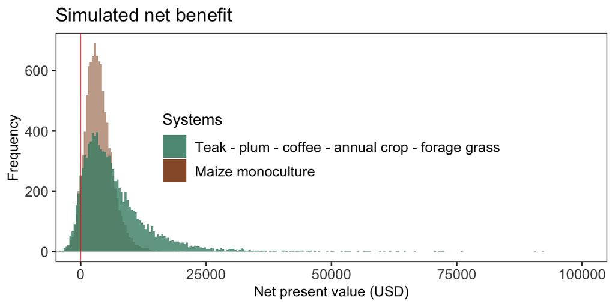

The graphs below show the outcomes for both the sensitivity analysis (left) and Value of Information analysis (right).

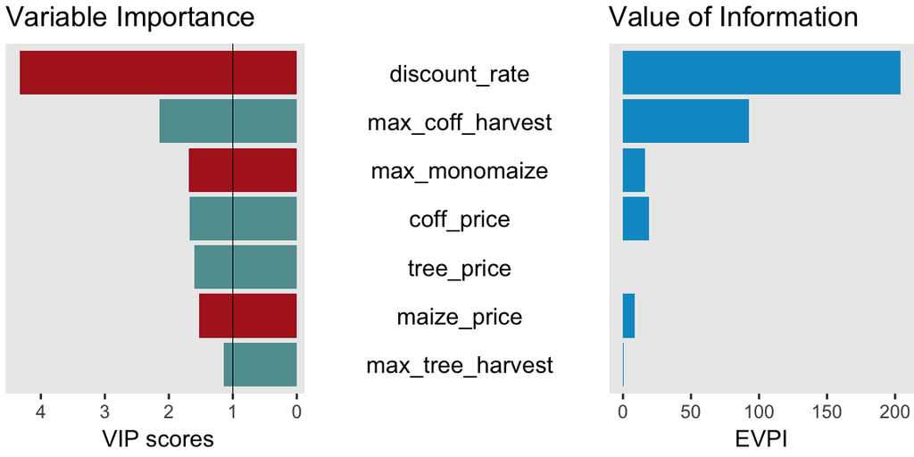